# Chapter 8: A Closer Look at Assumptions for Simple Linear Regression

Loren Serfass

02/12/2015

# Chapter 8: A Closer Look at Assumptions for Simple Linear Regression

# This chapter's examples

## Island area and number of species

This dataset gives the area and number of animal species (reptile and amphibian) of 7 islands in the West Indies. Here is the whole dataset:

```r
##    area species
## 1 44218     100
## 2 29371     108
## 3  4244      45
## 4  3435      53
## 5    32      16
## 6     5      11
## 7     1       7
```

The data does not lie close to a straight line, but it does if both variables are log-transformed.

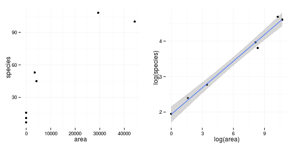

## Breakdown times for insulating fluid under different voltages

Here, logging the y scale results in a fairly linear relationship.

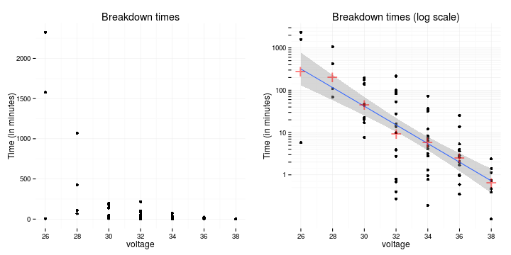

# Chapter notes

Linear models assume: *linearity, constant variance, normality, and independence*. If the true relationship between the variables is far enough from linear, then predictions are *biased*, over- or under- estimating. ... Violations of the *normality* assumption don't cause a lot of inaccuracy in the coefficient estimates, but prediction intervals will be inaccurate. If observations are *not independent*, cluster and serial effects should be incorporated into models.

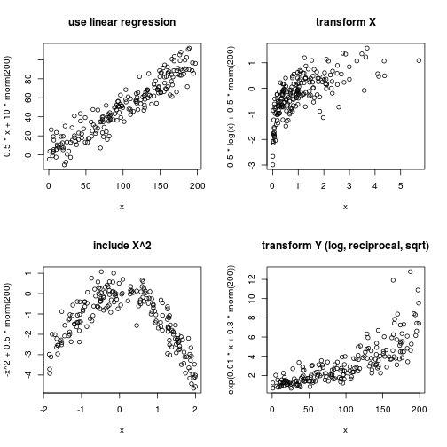

Plotting residuals vs fitted values to assess a model. First, modeling the untransformed `time`.

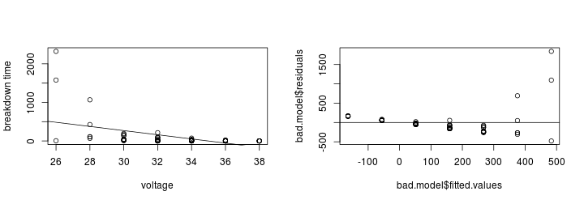

Trying the square root of breakdown time:

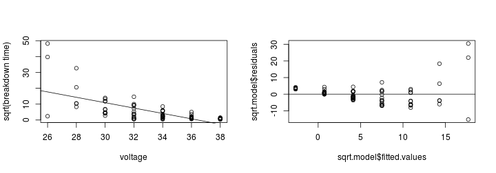

Trying the log of breakdown time. The variance in this model seems fairly constant.

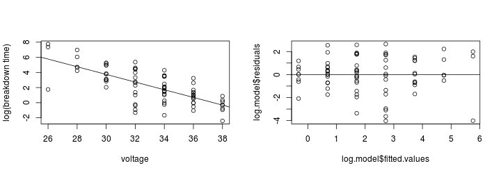

Plotting the three models on the same plot. On the log scale, the black and red lines don't continue because they go below 0.

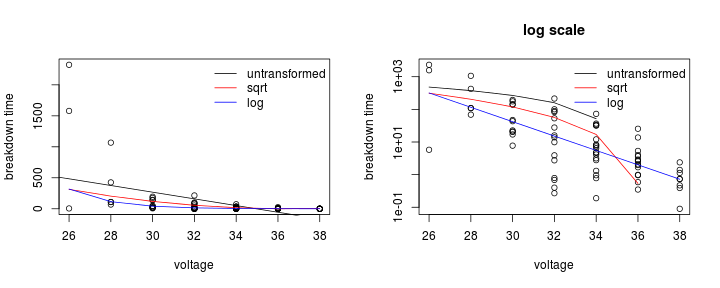

## Interpretation after log transformations

When only Y is logged: *use medians*. When X increases by 1, Y's median is multiplied.

When X is logged: a [doubling of] X is associated with adding a constant amount to Y.

When both X and Y are logged: a [doubling of X] is associated with multiplying Y's median by a constant factor.

## Assessment of fit using ANOVA

Two ANOVAs are given. Here is a comparison of `separate.means` with `equal.means`:

```r
## Analysis of Variance Table
##
## Model 1: log(time) ~ as.factor(voltage)
## Model 2: log(time) ~ 1
##   Res.Df RSS Df Sum of Sq  F  Pr(>F)
## 1     69 174
## 2     75 370 -6      -196 13 8.9e-10 ***
## ---
## Signif. codes:  0 '***' 0.001 '**' 0.01 '*' 0.05 '.' 0.1 ' ' 1
```

And here is a comparison of `linear.model` with `equal.means`:

```r
## Analysis of Variance Table
##
## Model 1: log(time) ~ voltage
## Model 2: log(time) ~ 1
##   Res.Df RSS Df Sum of Sq    F  Pr(>F)
## 1     74 180
## 2     75 370 -1      -190 78.1 3.3e-13 ***
## ---
## Signif. codes:  0 '***' 0.001 '**' 0.01 '*' 0.05 '.' 0.1 ' ' 1
```

The third comparison, between `separate.means` and `linear.model`, is called a **Lack-of-Fit F-Test**. It tests the adequacy of the straight-line model.

```r
## Analysis of Variance Table
##
## Model 1: log(time) ~ as.factor(voltage)
## Model 2: log(time) ~ voltage
##   Res.Df RSS Df Sum of Sq   F Pr(>F)
## 1     69 174
## 2     74 180 -5     -6.33 0.5   0.77
```

```r
## Analysis of Variance Table
##
## Model 1: log(time) ~ as.factor(voltage)
## Model 2: log(time) ~ voltage
## Model 3: log(time) ~ 1
##   Res.Df RSS Df Sum of Sq    F  Pr(>F)
## 1     69 174
## 2     74 180 -5      -6.3  0.5    0.77
## 3     75 370 -1    -190.2 75.5 1.1e-12 ***
## ---
## Signif. codes:  0 '***' 0.001 '**' 0.01 '*' 0.05 '.' 0.1 ' ' 1
```

# Conceptual Exercises

[figure not shown]

Styled with knitrBootstrap